# Probability, Odds, and Simple Logistic Regression

# Probability and Odds Solutions

## Exercise 1: Exploring First Steps enrollment and Gestational Age

```r
# 2x2 Table: preterm vs. First Steps
firststeps %>%
    count(preterm, firstep)
## # A tibble: 4 × 3
##   preterm firstep     n
##   <chr>     <dbl> <int>
## 1 No            0  1879
## 2 No            1   343
## 3 Yes           0   218
## 4 Yes           1    60
```

1. 343 + 60 = 403 parents were enrolled in the First Steps program. I used both rows of the table where `firstep = 1`.
2. 16.12% of people in the study were enrolled in First Steps!

```r
403 / 2500
## [1] 0.1612
```

3. 60 birth parents
4. 14.89% of birth parents in First Steps had a premature baby.

```r
60 / 403
## [1] 0.1488834
```

5. The total number of birth parents who had a premature baby was 218 + 60 = 278. Of those. 60 were enrolled in First Steps. Therefore, 21.58% of birth parents who had a premature baby were enrolled in First Steps.

```r
60/278
## [1] 0.2158273
```

Using formal probability notation, we can write

> 2. $P(\text{First Steps})$ = .1612
> 4. $P(\text{Preterm} | \text{First Steps})$ = .1488
> 5. $P(\text{First Steps} | \text{Preterm})$ = .2158

> $P(\text{Preterm} | \text{Not in First Steps})$ = 218 / (218 + 1879) = 0.103958

$$\frac{(\text{Preterm} | \text{First Steps})}{P(\text{Preterm} | \text{Not in First Steps})} = .1488 / 0.103958 = 1.43$$

8. Parents in this study in the First Steps program are 1.43 times more likely to have a premature birth than those not enrolled in the First Steps program, indicating that gestational age does differ by First Steps enrollment. This implies that enrollment in the First Steps program may not be associated with better birth outcomes, as measured by gestational age.

*Note:* However, you may argue that this is not a fair comparison, or that this summary is not what researchers were actually interested in! Ideally, we would compare birth outcomes from mothers in the First Steps program to the birth outcomes from *those same mothers* not in the First Steps program, to determine if the program made a positive impact. This idea hints at a sub-field of statistics called **causal inference** and the idea of a **counterfactual** (“what would have happened if…”). Take more statistics classes to learn about other methods for approaching this question!

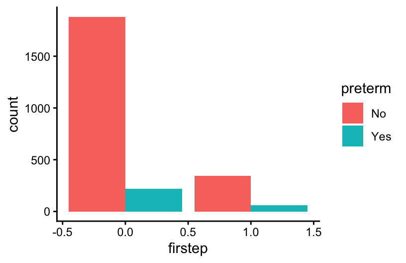

```r
# Side-by-side bar chart
firststeps %>%
  ggplot(aes(firstep, fill = preterm)) +
  geom_bar(position = "dodge") +
  theme_classic()
```

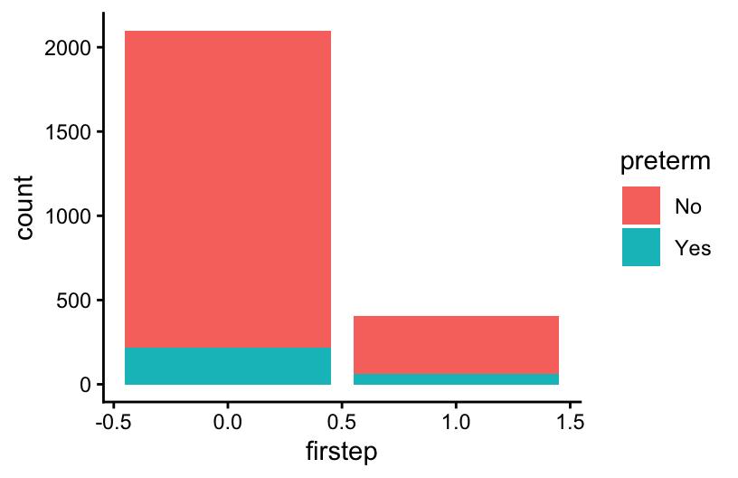

```r
# Stacked bar chart
firststeps %>%
  ggplot(aes(firstep, fill = preterm)) +
  geom_bar() +
  theme_classic()
```

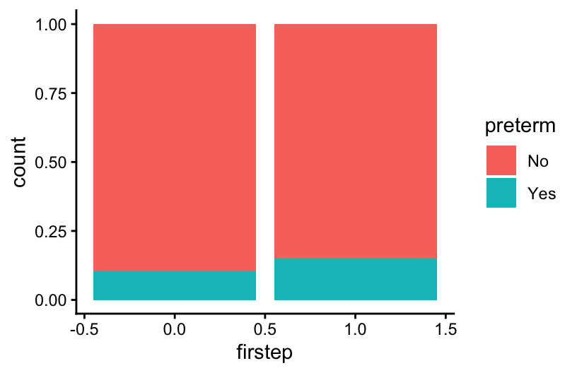

```r
# Stacked relative frequency bar chart
firststeps %>%
  ggplot(aes(firstep, fill = preterm)) +
  geom_bar(position = "fill") +
  theme_classic()
```

**Bonus Question:** Which of the above three plots allows you to directly see the conditional probabilities we calculated previously?

> The stacked relative frequency bar chart!

## Exercise 2: Exploring First Steps enrollment and Low birthweights

```r
# 2x2 Table: low_bwt vs. First Steps
firststeps %>%
  count(low_bwt, firstep)
## # A tibble: 4 × 3
##   low_bwt firstep     n
##   <chr>     <dbl> <int>
## 1 low           0   102
## 2 low           1    25
## 3 not low       0  1995
## 4 not low       1   378
```

> $P(\text{Low birth weight} | \text{First Steps})$ = 25 / (25 + 378) = 0.062

> $P(\text{Normal birth weight} | \text{First Steps})$ = 378 / (25 + 378) = 0.938

> $P(\text{Low birth weight} | \text{Not in First Steps})$ = 102 / (102 + 1995) = 0.049

> $P(\text{Normal birth weight} | \text{Not in First Steps})$ = 1995 / (102 + 1995) = 0.951

> $Odds(\text{Low birth weight} | \text{First Steps})$ = 0.062 / (1 - 0.062) = 0.06609808

> $Odds(\text{Normal birth weight} | \text{First Steps})$ = 0.938 / (1 - 0.938) = 15.12903

> $Odds(\text{Low birth weight} | \text{Not in First Steps})$ = 0.049 / (1 - 0.049) = 0.05152471

> $Odds(\text{Normal birth weight} | \text{Not in First Steps})$ = 0.951 / (1 - 0.951) = 19.40816

```r
0.06609808 / 0.05152471
## [1] 1.282842
```

5. The odds of having a low birth weight baby are 1.28 times higher for those enrollment in First Steps compared to those not in First Steps. Just as in Exercise 1, this implies that the First Steps program may not be associated with improved birth outcomes (with the same caveats as given in the answer to 1 (h)).
6. To go along with your summary, add code below to make one of the three visualization options we tried out in Exercise 1.

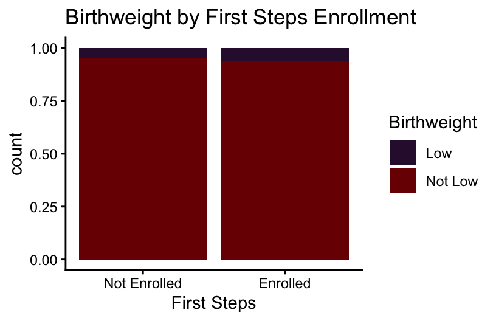

```r
# Stacked relative frequency bar chart (with some fancy aesthetics)
firststeps %>%
  mutate(Birthweight = low_bwt %>% str_to_title()) %>%
  ggplot(aes(firstep, fill = Birthweight)) +
  geom_bar(position = "fill") +
  theme_classic() +
  scale_fill_viridis_d(option = "H") +
  labs(x = "First Steps", title = "Birthweight by First Steps Enrollment") +
  scale_x_continuous(breaks = c(0,1), labels = c("Not Enrolled", "Enrolled"))
```

## Exercise 3: Conditional vs. Marginal probabilities

Suppose we select a person at random from the entire global population. For each of the following probabilities, which do you think is bigger? Explain your reasoning.

1. P(lung cancer | smoker) is likely bigger, since lung cancer is more rare in the general population than it is among smokers.
2. P(likes McDonald’s) is likely bigger, since vegetarians don’t likely like McDonald’s very much (few options that they can eat).
3. P(smart | Mac grad) is likely bigger, because there are *very* few Mac grads relative to the global population. Lots of people are smart, few are Mac grads.

## Exercise 4: Probability practice

Let’s explore whether birth weight of a baby varies by whether or not it was the *first* child that a mother had, *and* whether this relationship differs by First Steps enrollment. We make a table below:

```r
firststeps %>%
  count(firstchild, low_bwt, firstep)
## # A tibble: 8 × 4
##   firstchild low_bwt firstep     n
##   <chr>      <chr>     <dbl> <int>
## 1 No         low           0    43
## 2 No         low           1    13
## 3 No         not low       0  1080
## 4 No         not low       1   198
## 5 Yes        low           0    59
## 6 Yes        low           1    12
## 7 Yes        not low       0   915
## 8 Yes        not low       1   180
```

1. What is the probability that a mother enrolled in First steps who is having their first child, has a baby who is born at a low birthweight? Calculate your answer, and write it using formal probability notation.

# Logistic Univariate Solutions

## Exercise 1: Exploring age

The boxplot doesn’t clearly indicate a difference in the age distributions across survivors and non-survivors, but we do notice from the density plot that there is a greater density of younger passengers among the survivors. We also see from the last plot that younger passengers tend to have a higher survival chance.

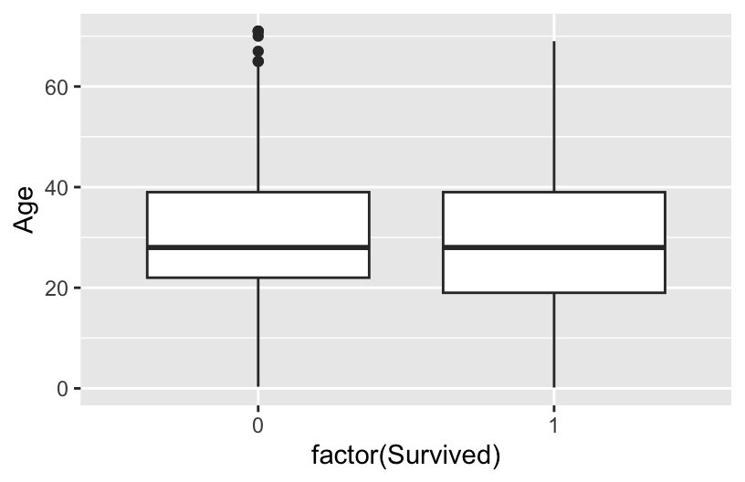

```r
# Create a boxplot
ggplot(titanic, aes(x = factor(Survived), y = Age)) +
    geom_boxplot()
```

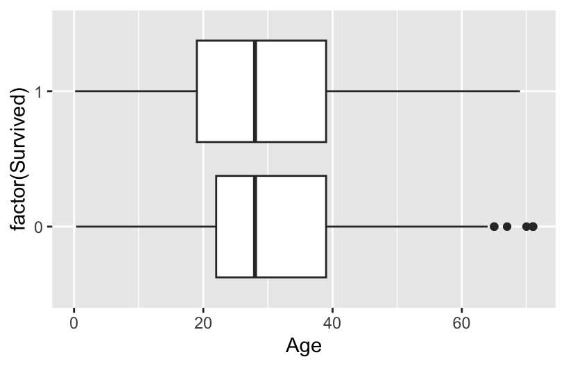

```r
# Can flip the boxplot on its side too
ggplot(titanic, aes(y = factor(Survived), x = Age)) +
    geom_boxplot()
```

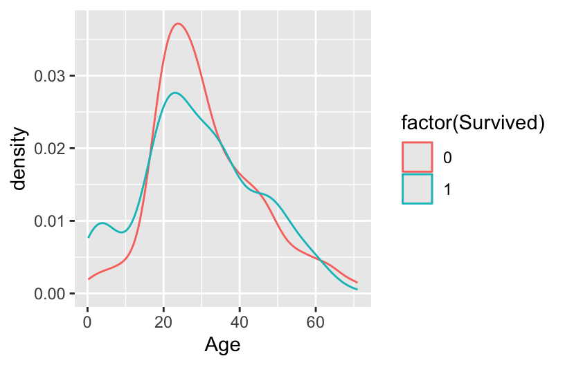

```r
# Create a density plot
ggplot(titanic, aes(x = Age, color = factor(Survived))) +
    geom_density()
```

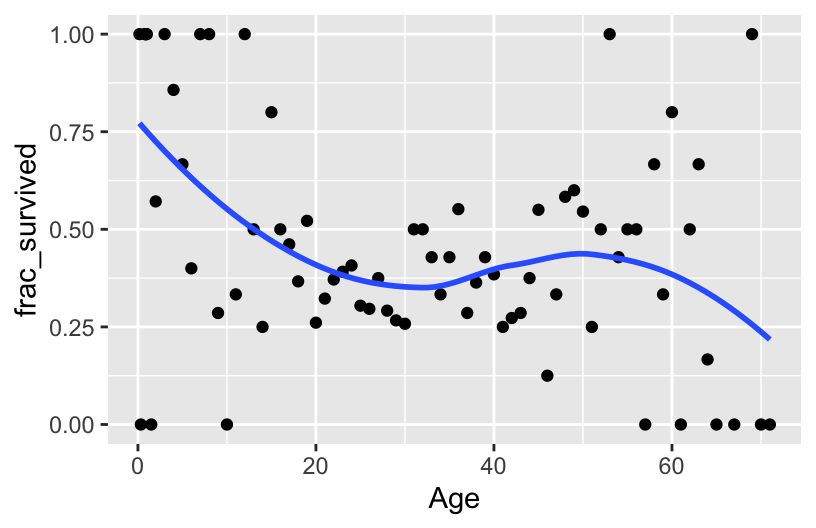

```r
# Use the code below to create a plot of the fraction who survived at each age
titanic_summ <- titanic %>%
    group_by(Age) %>%
    summarize(frac_survived = mean(Survived))

ggplot(titanic_summ, aes(x = Age, y = frac_survived)) +
    geom_point() +
    geom_smooth(se = FALSE)
```